# Registration, Pre-Analysis Plans and Reporting Guidelines

Introduction, Hands-on with the Open Science Framework (OSF) and AEA Registry

Fernando Hoces de la Guardia BITSS - Slides at https://goo.gl/aBQ3LR

Inter-American Development Bank Workshop, March 2018

# Little experiment [10mins]

## Explanation to participants

### Read and complete the sheet: DO NOT LOOK AT OTHERS SHEETS

### Go to the website bellow and complete with your answers.

## Explanation to researchers

### You just participated in (highly simplified) version of **The Ultimatum Game**

### The goal of the UG is to measure attitudes about fairness and/or expectations about (econ) rational behavior.

### Our little experiment was trying to measure if the responses to the UG can be anchored by a completly irrelevant number:

The ID number at the beginning of your sheet!

## Explanation to researchers

### Treatment was receiving an ID number between 960 and 999.

### Control receive an ID number between 10 and 49.

### Outcome: Offer made in the UG

### For the hands-on excercise, you can use this experiment, or work with your own paper/project.

# Registration & PAP: What

## What is a Registration and a PAP?

# Registration & PAP: Why

## Publication Bias Across Social Science

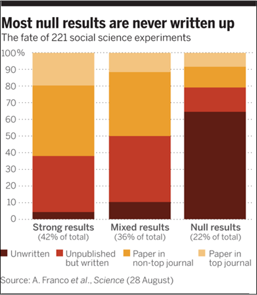

## Why Do We Need PAPs?

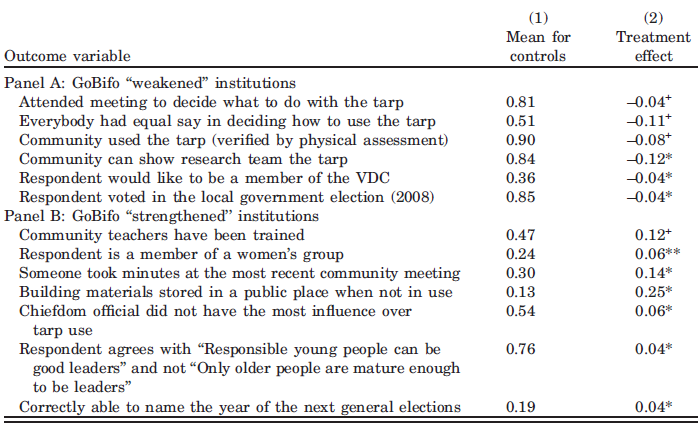

## Why Do We Need PAPs? The Social Planner View (Haushofer, 2017)

**Benefits:**  
1. Improves transparency: clear ex ante what the researcher planned  
2. Reduces false positives: fewer forking paths, less p-hacking  
3. Reduces the filedrawer problem; others can ask what happened to your project.

**Costs:**  
1. Time cost. I don’t think this is very large, see below.  
2. Stifles exploratory work. I don’t think this is true, see below.  
3. Pre-specifying the wrong analyses (ex ante or ex post). This is potentially serious.

**Reducing costs:**  
1. Time cost: make the PAP your methods section later.  
2. Exploratory work: datamine to your heart’s delight! Just be honest about it.  
3. Pre-specifying the wrong analyses: Be honest about your thought process and hope for sensible readers/referees.

## Hands-on Registration.

Based on a project of your own, or on our little experiment:

- Create a draft of using Open Science Framework at osf.io:
  - Open format
  - AsPredicted (will work with this one)
- Explore AEA Registry at www.socialscienceregistry.org

## Registration of our Little Experiment

Using Aspredicted format:  
- **Research question:** Does exposure to a large number increases the offer made in the ultimatum game?  
- **Dependent variable:** Amount offered in the ultimatum game.  
- **Manipulation/Conditions:** Participant will be randomly assigned a large number ([960, 999]) or a small number ([10, 49]) to be read and remember, before reading the ultimatum game question.  
- **Analyses:** OLS regression of amount offer as dependant variable and treatment as regressor.  
- **Outliers and Exclusions:** Will exclude participants with missing information in any field. Amounts beyond plausible values (eg offers above max dollar value) will be will be top-coded.  
- **Sample size:** We will define our sample by the number of participants in the workshop.

## How to do a PAP? Glennerster & Takavarasha Suggestions

Report:

- The main outcome measures.
- Which outcome measures are primary and which are secondary.
- The precise composition of any families that will be used for mean effects analysis.
- The subgroups that will be analyzed.
- The direction of expected impact if we want to use a one-sided test.
- The primary specification to be used for the analysis.

## How to do a PAP? McKenzie Suggestions

[World Bank Development Impact Blog](http://blogs.worldbank.org/impactevaluations/a-pre-analysis-plan-checklist)

- Description of the sample to be used in the study
- Key data sources
- Hypotheses to be tested throughout the causal chain
- Specify how variables will be constructed
- Specify the treatment effect equation to be estimated
- What is the plan for how to deal with multiple outcomes and multiple hypothesis testing?
- Procedures to be used for addressing survey attrition
- How will the study deal with outcomes with limited variation?
- If you are going to be testing a model, include the model
- Remember to archive it

## How to do a PAP? Specific Resources

- Pre-reg Challenge (emph IRB)
- RR at JDE

## Difference between Registration and PAP?

- Key difference is the amount of detail/effort.
- Registration: very easy, goal is to address publication bias.
- PAP:
- It is more a matter of degree.

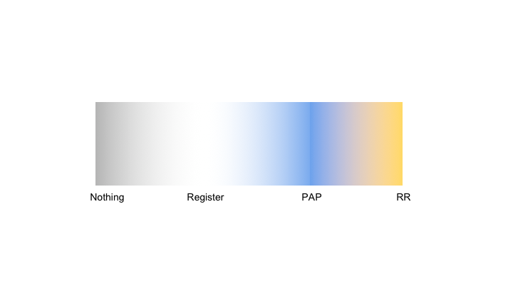

## Summary

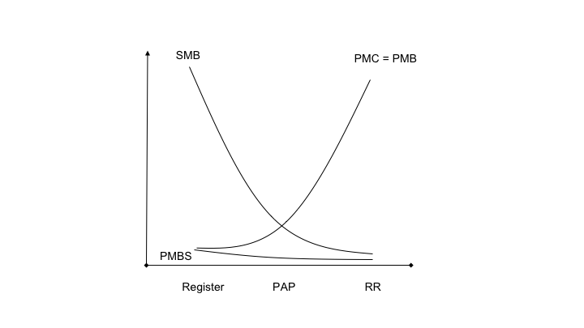

## When should you do a PAP or a Registration?

Time dimention.

Research design dimension.

# Reporting Guidelines [20mins]

## Why Do We Need Reporting Guidelines?

Defines minimal set of elements required in a scientific paper. Helps with:  
- Structured PAPs  
- Replicability  
- Meta-analysis

## How to follow Reporting Guidelines

- CONSORT Guidelines & EQUATOR network.
- Recent APA guidelines.
- JDE suggested guidelines for register reports.

## CONSORT Guidelines & EQUATOR network.

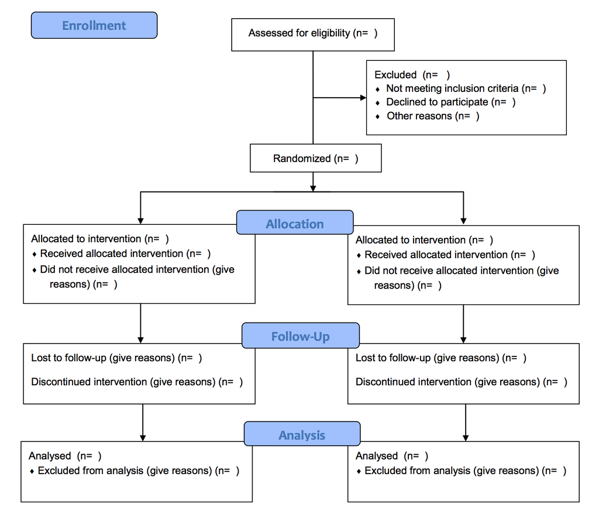

## CONSORT Guidelines & EQUATOR network.

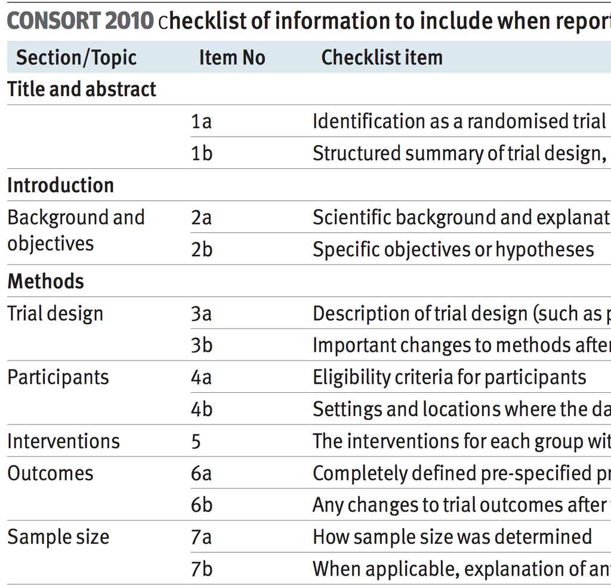

EQUATOR Network: website containing more than 300 other guidelines.